# MScA, Bayesian Methods (32014) Week 3 Workshop

Yuri Balasanov, © iLykei 2016

# 1 References

[G] Andrew Gelman, John B. Carlin, Hal S. Stern, David B. Dunson, Aki Vehtari, Donald B. Rubin, Bayesian Data Analysis, Third Edition, 2013, Taylor & Francis Group.  
[K] John K. Kruschke, Doing Bayesian Data Analysis, A Tutorial with R, JAGS, and STAN, 2015, Elsevier.

# 2 Review of binomial model

The goal of the experiment is estimation of conversion rate based on trial of marketing campaign with 100 participants.

**Step 1**. Define model: data are generated by binomial distribution with parameter $\theta$
$$y_i \sim Binom(\theta).$$
**Step 2**. Define prior distribution for parameter $\theta$
$$\theta \sim Beta(\alpha,\beta).$$
Interpretation of the model: each member of the population has individual conversion rate, i.e. conversion rates form a population with beta distribution.
Define prior distribution with mode $\omega=5\%$ and concentration $\kappa=100$.
Use formulas to calculate parameters of beta distribution from mode and concentration:
$$\alpha=\omega(\kappa-2)+1,~~\beta=(1-\omega)(\kappa-2)+1, \kappa>2.$$
(Do it yourself)

```r
omega<-.05
kappa<-100
a<-omega*(kappa-2)+1
b<-(1-omega)*(kappa-2)+1
```

```r
c(a=a,b=b)
```

```
##    a    b
##  5.9 94.1
```

Plot the prior density

(Do it yourself)

```r
x<-seq(from=0,to=1,by=.001)
priorBetaDens<-dbeta(x,shape1=a,shape2=b)
```

```r
x[which.max(priorBetaDens)]
```

```
## [1] 0.05
```

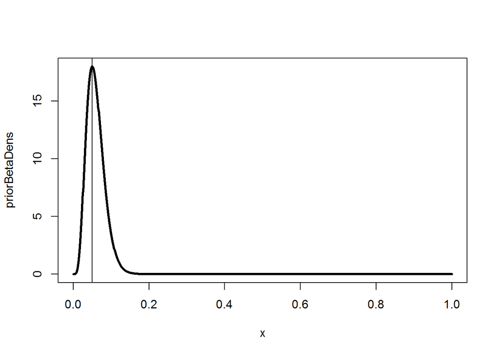

```r
plot(x,priorBetaDens,type='l',lwd=3)
abline(v=.05)
```

**Step 3**. Obtain the sample

Sample is a sequence of 100 observations of zeros (no conversion) or ones (conversion). But it is enough to know *sufficient statistics*: number of successes $k$ and total number of observations $s$.

```r
(smple<-c(rep(0,times=92),rep(1,times=8)))
```

```
##   [1] 0 0 0 0 0 0 0 0 0 0 0 0 0 0 0 0 0 0 0 0 0 0 0 0 0 0 0 0 0 0 0 0 0 0 0
##  [36] 0 0 0 0 0 0 0 0 0 0 0 0 0 0 0 0 0 0 0 0 0 0 0 0 0 0 0 0 0 0 0 0 0 0 0
##  [71] 0 0 0 0 0 0 0 0 0 0 0 0 0 0 0 0 0 0 0 0 0 0 1 1 1 1 1 1 1 1
```

```r
(k<-sum(smple))
```

```
## [1] 8
```

```r
(s<-length(smple))
```

```
## [1] 100
```

**Step 4**. Find posterior distribution

Since beta distribution is conjugate with binomial posterior disribution is also beta.
Calculate parameters of posterior distribution using
$$\alpha_{posterior}=k+\alpha_{prior},~~\beta_{posterior}=s-k+\beta_{prior}.$$
(Do it yourself)

```r
postA<-k+a
postB<-s-k+b
posteriorBetaDens<-dbeta(x,shape1=postA,shape2=postB)
```

```r
c(postA=postA,postB=postB)
```

```
## postA postB
##  13.9 186.1
```

The posterior distribution has new mode that can be calculated by formula $\omega=\frac{\alpha - 1}{\alpha+\beta-2}$ for $\alpha,\beta>1$, or directly from the plot of the density:

```r
x[which.max(posteriorBetaDens)]
```

```
## [1] 0.065
```

Plot prior and posterior distributions.

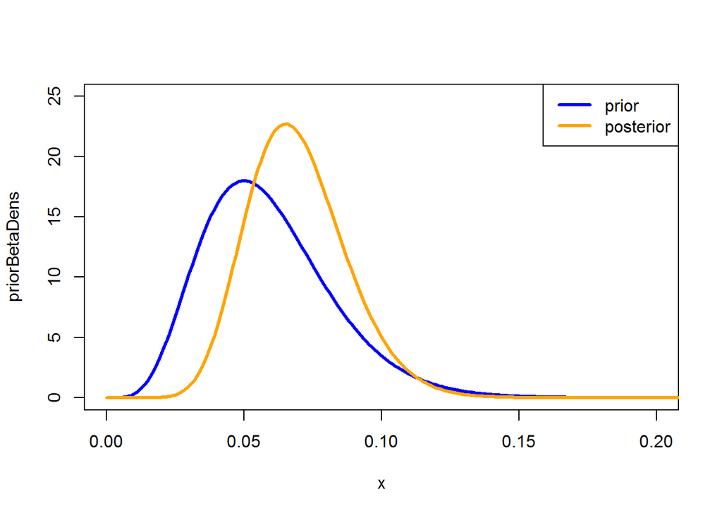

```r
plot(x,priorBetaDens,type='l',lwd=3,col='blue',ylim=c(0,25),xlim=c(0,.2))
lines(x,posteriorBetaDens,lwd=3,col='orange')
legend("topright",legend=c("prior","posterior"),col=c("blue","orange"),lwd=3)
```

**Step 5**. Make conclusions

Posterior distibution contains all information about the population of conversion rates.
Point Bayesian estimate of conversion rate is the mean of the posterior distribution:
$$\mathbf{E}[X_B] =\mu= \frac{\alpha }{\alpha + \beta} ; \quad
\mathbf{V}[X_B]=\sigma^2= \frac{\alpha \beta}{(\alpha + \beta)^2 (\alpha + \beta +1)}.$$

Calculate posterior mean.

(Do it yourself)

```r
(muPosterior=postA/(postA+postB))
```

```
## [1] 0.0695
```

Calculate posterior variance of conversion rate:

(Do it yourself)

```r
(varPosterior<-postA*postB/(postA+postB)^2/(postA+postB+1))
```

```
## [1] 0.00032174
```

What is the new concentration?

(Do it yourself)

```r
(kappaPosterior<-postA+postB)
```

```
## [1] 200
```

# 3 Exchangeability and sampling

Example in section 5.2 of [G].

## 3.1 Data

For selected 8 states recorded divorce rates per 1000 population in 1981 are: $y=[y_1,y_2,y_3,y_4,y_5,y_6,y_7,y_8]$.

What can we say about $y_8$?

There is no information that allows distinguishing this observation from others, so we have to assume that the joint prior distribution is exchangeable.

## 3.2 Data on 7 states out of 8

Now 7 out of 8 states are randomly selected and those observations are given to us:

```r
y.7<-c(5.8,6.6,7.8,5.6,7.0,7.1,5.4)
```

Again, what can we say about the remaining 8-th state?

A reasonable predictive posterior distribution would be based on the samle and centered around 6.5 with most of its mass concentrated between 5 and 8.

```r
summary(y.7)
```

```
##    Min. 1st Qu.  Median    Mean 3rd Qu.    Max.
##   5.400   5.700   6.600   6.471   7.050   7.800
```

Putting the remaining state rate at any position within the sample does not change the joint distribution. The data are still exchangeable.

## 3.3 Known group of states

The next additional prior information is: the 8 states are the Mountain states, i.e. Arizona, Colorado, Idaho, Montana, Nevada, New Mexico, Utah, Wayoming selected in random order.  
We still don’t know which divorce rate corresponds to which state.

With this information before the 7 state rates are observed the data should still be modelled exchangeably.  
But the prior for all 8 numbers must be different:  
* Utah has large Mormon population which makes divorce rate lower than other states  
* Nevada has more liberal divorce laws which makes the rate higher than in other states  
Such consideration may result in a wider tails of prior distribution to allow for outliers.

After observing the rates for random 7 states we notice that the numbers are close together.  
It might mean that the missing state is either Utah or Nevada.  
If that is true the posterior distribution might be bimodal or even trimodal.  
But the joint distribution on all 8 states is still exchangeable.

## 3.4 Known missing state

Now, if we learn that the missing state is Nevada, we cannot think of data as exchangeable even before the 7 state rates are revealed, since there is information distinguishing $y_8$ from other states: we expect it to be larger than others.  
After observing the 7 states we would expect the posterior distribution to have the property that $p(y_8>max(y_1,\ldots,y_7)|y_1,\ldots,y_7)$ is large.

Indeed the divorce rate per 1000 population in Nevada in 1981 was 13.9,

# 4 Binomial Model with hyperparameters

The model description that was considered earlier was:
$$y_i \sim Binom(\theta),$$
$$\theta \sim Beta(\alpha,\beta).$$

Parameters $(\alpha,\beta)$ were transformed into mode and concentration for $\alpha,\beta>1$:
$$\omega=\frac{\alpha - 1}{\alpha+\beta-2}$$
,
$$\kappa=\alpha+\beta.$$
And the reverse transformation is
$$\alpha=\omega(\kappa-2)+1,~~\beta=(1-\omega)(\kappa-2)+1, \kappa>2.$$

Then parameters $\omega,\kappa$ were assumed constants fixed from previous knowledge.
Posterior distribution was estimated as
$$p(\theta|y) \propto Beta(\alpha+k,s-k+\beta),$$
where $(s,k)$ were the observed number of Bernoulli experiments and the number of succeses in them.

To make the next step and create a chierarchical model assume that concentration $\kappa$ is still constant, but mode $\omega$ is random, so, we need to define a prior and find posterior distribution for it.

## 4.1 High concentration, uncertain hyperparameter

Let the prior distribution for $\omega$ be $Beta(A_{\omega},B_{\omega}),$ where $A_{\omega}$ and $B_{\omega}$ are constants.

A model with two parameters could in such case be:
$$p(\theta,\omega|y)=\frac{p(y|\theta,\omega)p(\theta,\omega)}{p(y)}=\frac{p(y|\theta)p(\theta|\omega)p(\omega)}{p(y)}.$$

Note that all 3 terms in the numerator are specified:
$$p(\omega)=Beta(A_{\omega},B_{\omega}),$$
$$p(\theta|\omega)=Beta(\omega,\kappa)$$
and the likelihood function is given by
$$y_i \sim Binom(\theta).$$

Both parameters have finite domain [0,1], so solve the problem by grid approximation.

Let $\kappa=100$ be fixed and $A_{\omega}=B_{\omega}=2$. These parameters correspond to density function

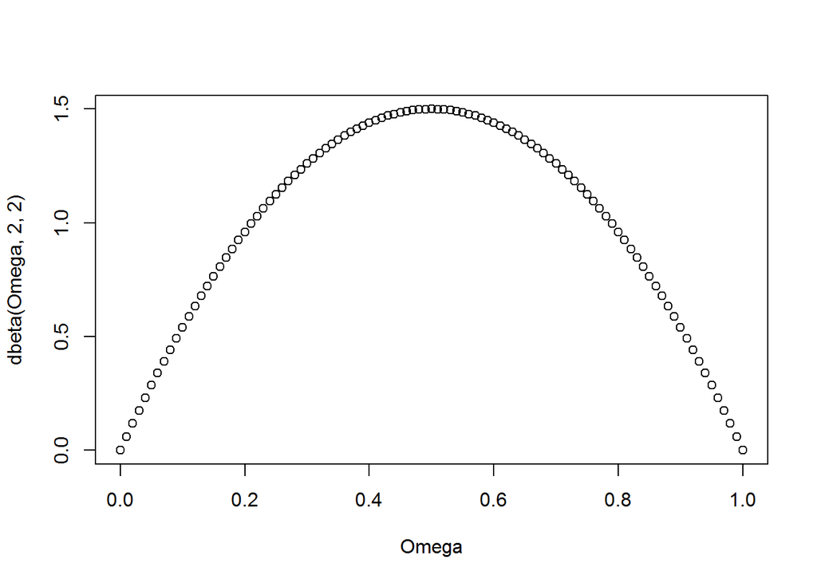

```r
Omega<-Theta<-seq( 0 , 1 , length=101 )
plot(Omega,dbeta(Omega,2,2))
```

The joint prior is:
$$p(\theta,\omega)=p(\theta|\omega)p(\omega)=dbeta(\theta|\omega(100-2)+1,(1-\omega)(100-2)+1)dbeta(\omega|2,2)$$

Define parameters of the hyperprior.

```r
A_omega<-2
B_omega<-2
K<-100
```

Calculate and visualize joint prior and its marginals.

```r
jointPrior<-function(theta,omega,A_omega,B_omega,K){
  res<-dbeta(omega,A_omega,B_omega)*dbeta(theta,omega*(K-2)+1,(1-omega)*(K-2)+1)
  res
}
```

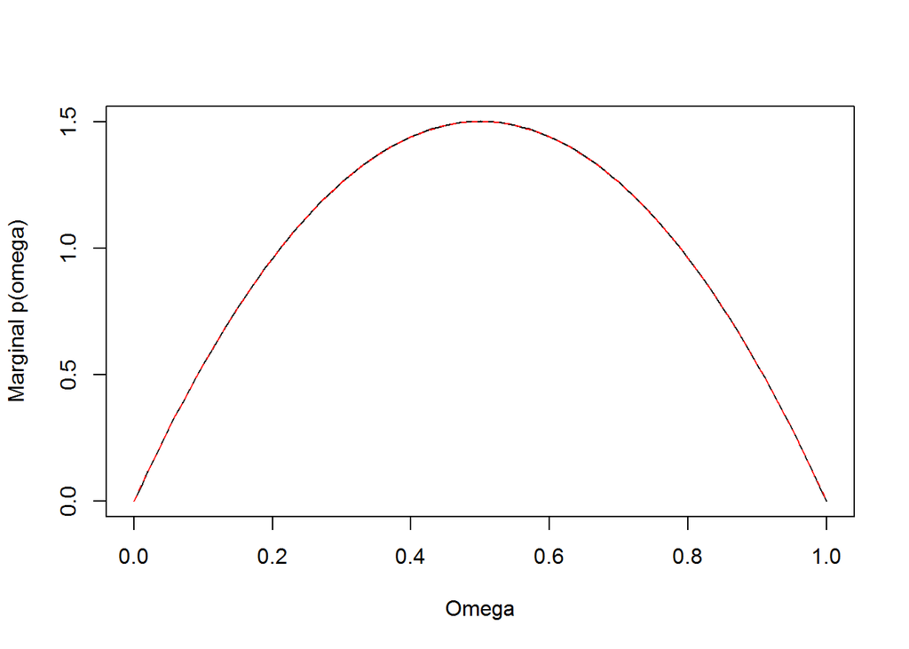

```r
dens<-expand.grid(Omega,Theta)
colnames(dens)<-c("Omega","Theta")
dens$Prior<-apply(dens,1,function(z) jointPrior(z[1],z[2],A_omega,B_omega,K))
Prior.theta.omega<-matrix(dens$Prior,101,101)
Prior.theta.omega<-Prior.theta.omega/sum(Prior.theta.omega) #Joint prior
Prior.omega.marginal<-apply(Prior.theta.omega,2,sum)
Prior.omega.marginal<-Prior.omega.marginal/sum(Prior.omega.marginal)*100 #Omega marginal prior
matplot(Omega,cbind(Prior.omega.marginal,dbeta(Omega,A_omega,B_omega)),type="l",ylab="Marginal p(omega)")
```

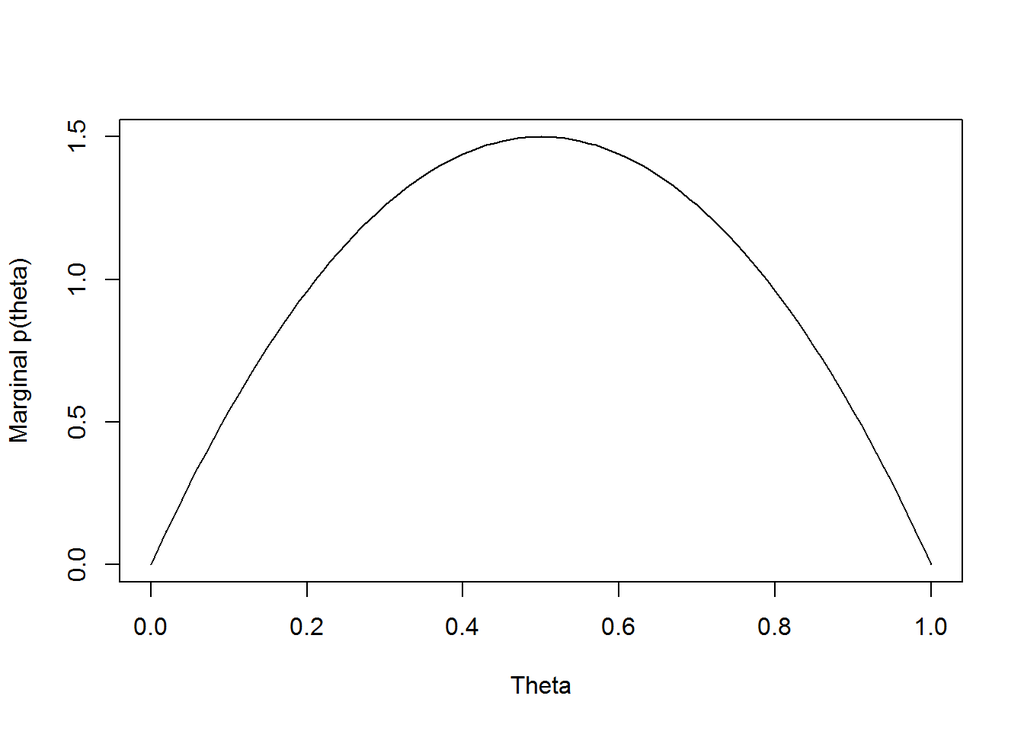

```r
Prior.theta.marginal<-apply(Prior.theta.omega,1,sum)
Prior.theta.marginal<-Prior.theta.marginal/sum(Prior.theta.marginal)*100 #Theta marginal prior
plot(Theta,Prior.theta.marginal,type="l",ylab="Marginal p(theta)")
```

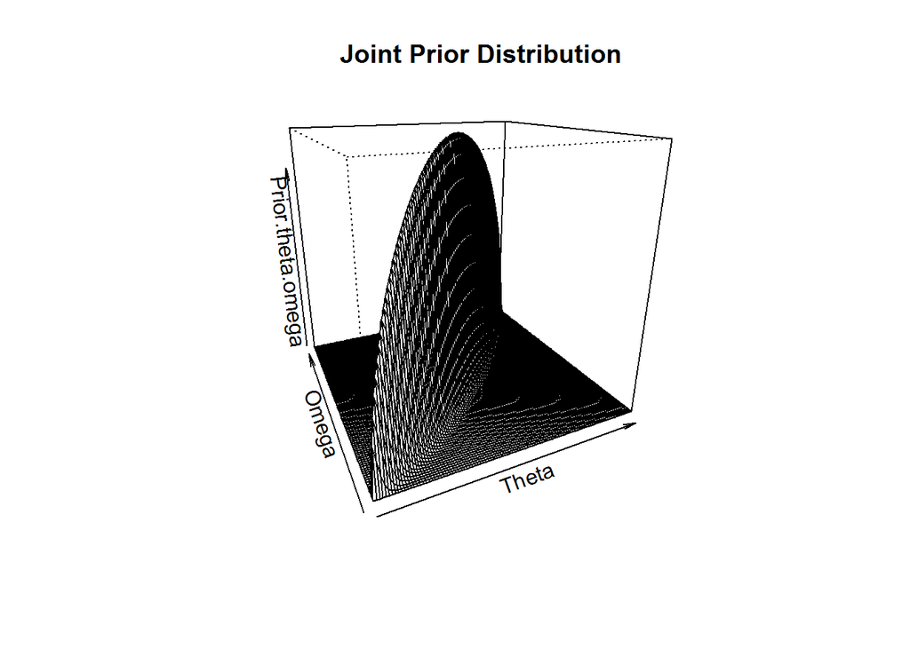

```r
persp(Theta,Omega,Prior.theta.omega,d=1,theta=-25,phi=20,main="Joint Prior Distribution")
```

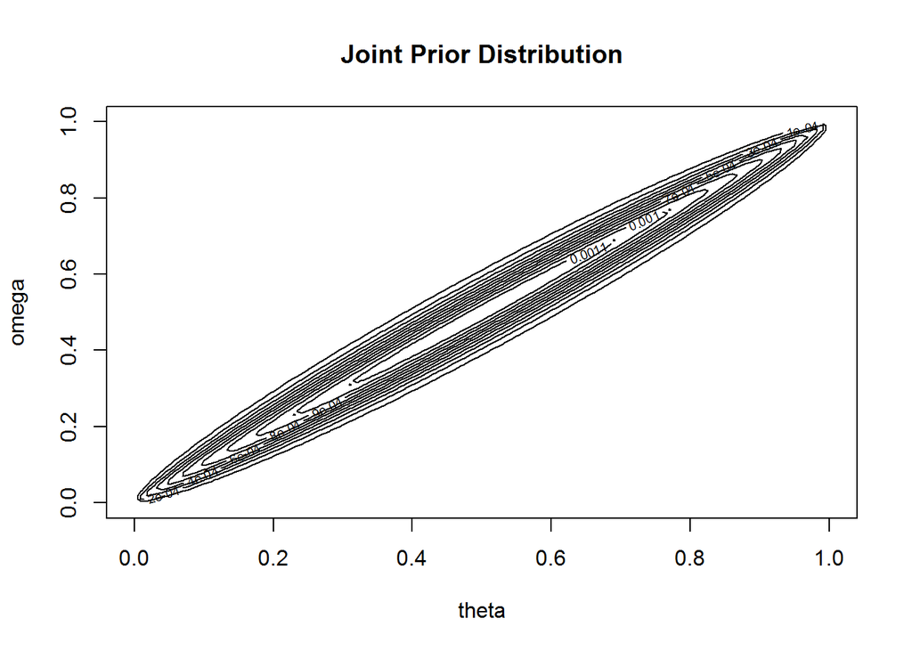

```r
contour(x=Omega,y=Theta,z=Prior.theta.omega,ylab="omega",xlab="theta",main="Joint Prior Distribution")
```

Show dependence of $\theta$ on $\omega$.

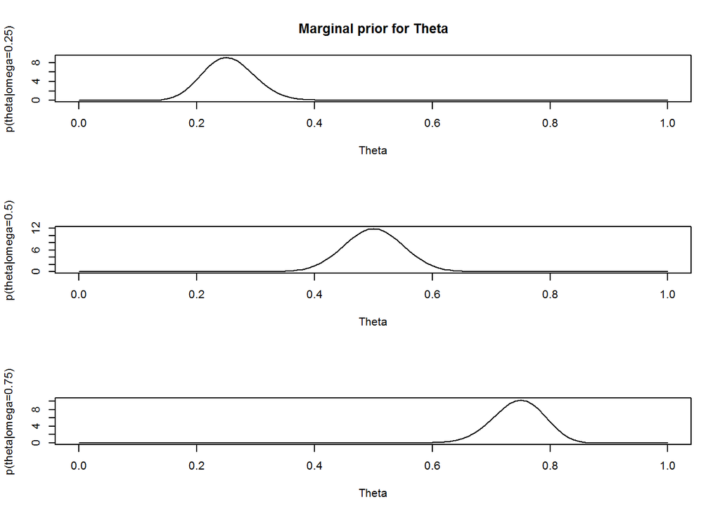

```r
par(mfrow=c(3,1))
Prior.theta.omega.25<-jointPrior(Theta,0.25,A_omega,B_omega,K)
Prior.theta.omega.25<-Prior.theta.omega.25/sum(Prior.theta.omega.25)*100
plot(Theta,Prior.theta.omega.25,type="l",ylab="p(theta|omega=0.25)",main="Marginal prior for Theta")
Prior.theta.omega.5<-jointPrior(Theta,0.5,A_omega,B_omega,K)
Prior.theta.omega.5<-Prior.theta.omega.5/sum(Prior.theta.omega.5)*100
plot(Theta,jointPrior(Theta,0.5,A_omega,B_omega,K),type="l",ylab="p(theta|omega=0.5)")
Prior.theta.omega.75<-jointPrior(Theta,0.75,A_omega,B_omega,K)
Prior.theta.omega.75<-Prior.theta.omega.75/sum(Prior.theta.omega.75)*100
plot(Theta,jointPrior(Theta,0.75,A_omega,B_omega,K),type="l",ylab="p(theta|omega=0.75)")
```

```r
par(mfrow=c(1,1))
```

The likelihood is based on the data of 9 successes out of 12 Bernoulli trials:
$$p(y|\theta)=\theta^9(1-\theta)^3.$$

```r
likeli<-function(theta,s,k){
  theta^k*(1-theta)^(s-k)
}
```

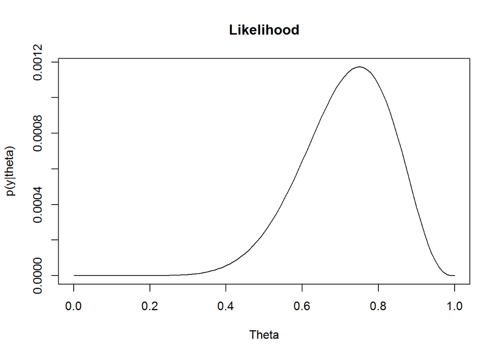

```r
likelihood<-likeli(Theta,12,9)
plot(Theta,likelihood,type="l",ylab="p(y|theta)",main="Likelihood")
```

Likelihood directly depends only on $\theta$, but not on $\omega$.

Posterior distribution is obtained by multiplication of the joint prior by likelihood at each point $(\theta_i,\omega_j)$.

(Do it yourself)

```r
Posterior<-apply(Prior.theta.omega,2,function(z) z*likelihood)
Posterior<-Posterior/sum(Posterior)
```

```r
Posterior[1:5,1:5]
```

```
##      [,1]         [,2]         [,3]         [,4]         [,5]
## [1,]    0 0.000000e+00 0.000000e+00 0.000000e+00 0.000000e+00
## [2,]    0 5.325178e-19 5.316759e-19 2.654016e-19 8.801408e-20
## [3,]    0 1.948110e-16 3.874865e-16 3.853395e-16 2.545789e-16
## [4,]    0 3.994671e-15 1.194150e-14 1.784762e-14 1.772124e-14
## [5,]    0 2.501667e-14 1.001516e-13 2.004610e-13 2.665593e-13
```

Plot the joint posterior distribution.

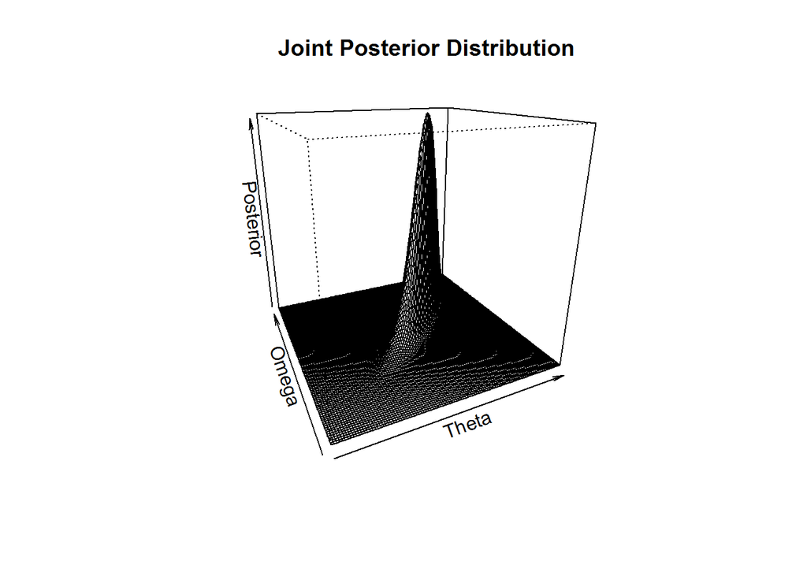

```r
persp(Theta,Omega,Posterior,d=1,theta=-25,phi=20,main="Joint Posterior Distribution")
```

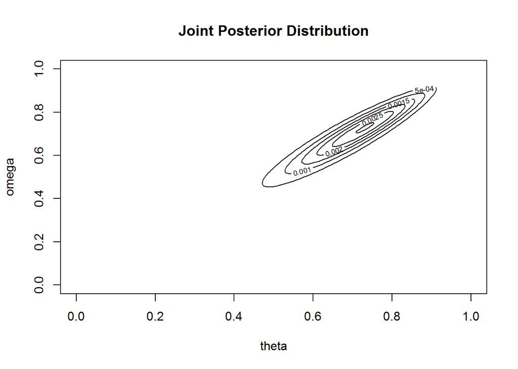

```r
contour(x=Omega,y=Theta,z=Posterior,ylab="omega",xlab="theta",main="Joint Posterior Distribution")
```

Calculate and plot posterior marginal distributions $p(\theta|y),~p(\omega|y)$ by adding the joint posterior matrix by row or by column.

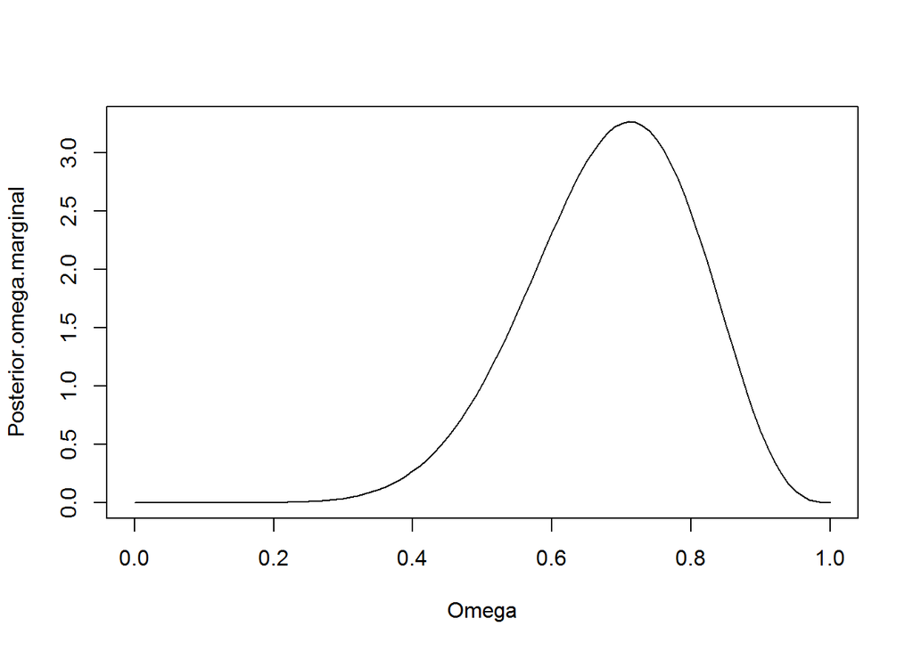

```r
Posterior.omega.marginal<-apply(Posterior,2,sum)
Posterior.omega.marginal<-Posterior.omega.marginal/sum(Posterior.omega.marginal)*100
plot(Omega,Posterior.omega.marginal,type="l")
```

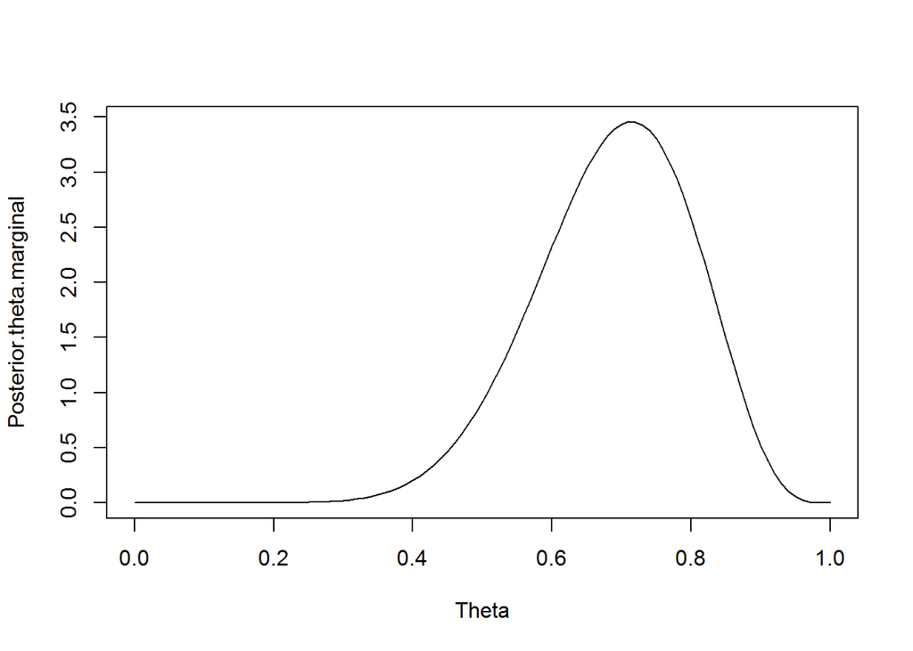

```r
Posterior.theta.marginal<-apply(Posterior,1,sum)
Posterior.theta.marginal<-Posterior.theta.marginal/sum(Posterior.theta.marginal)*100
plot(Theta,Posterior.theta.marginal,type="l")
```

Show dependence of $\theta$ on $\omega$.

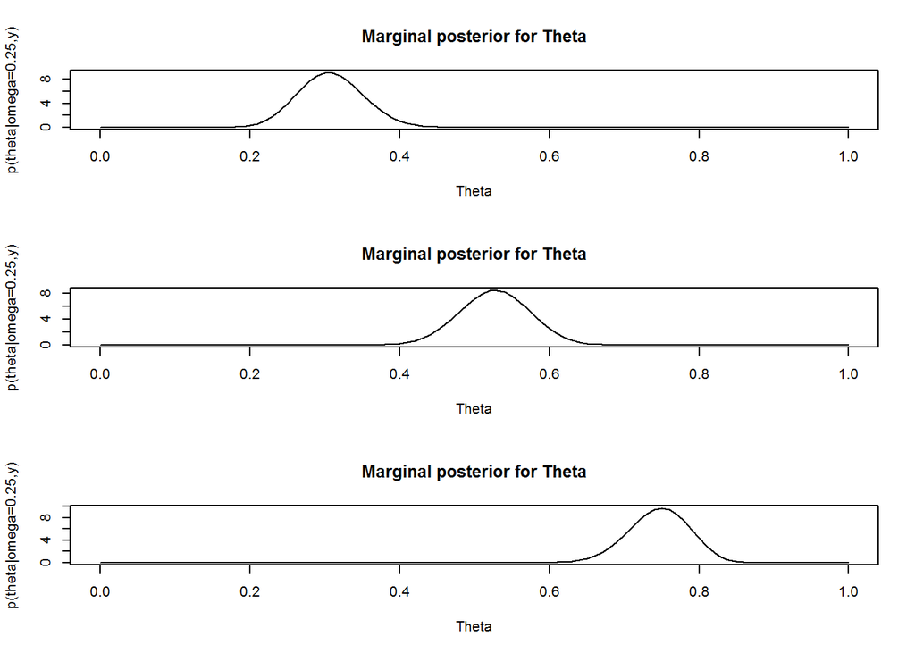

```r
par(mfrow=c(3,1))
#Omega=0.25
Post.theta.omega.25<-Posterior[,match(0.25,Omega)]
Post.theta.omega.25<-Post.theta.omega.25/sum(Post.theta.omega.25)*100
plot(Theta,Post.theta.omega.25,type="l",ylab="p(theta|omega=0.25,y)",main="Marginal posterior for Theta")
#Omega=0.5
Post.theta.omega.5<-Posterior[,match(0.5,Omega)]
Post.theta.omega.5<-Post.theta.omega.5/sum(Post.theta.omega.5)*100
plot(Theta,Post.theta.omega.5,type="l",ylab="p(theta|omega=0.25,y)",main="Marginal posterior for Theta")
#Omega=0.75
Post.theta.omega.75<-Posterior[,match(0.75,Omega)]
Post.theta.omega.75<-Post.theta.omega.75/sum(Post.theta.omega.75)*100
plot(Theta,Post.theta.omega.75,type="l",ylab="p(theta|omega=0.25,y)",main="Marginal posterior for Theta")
```

```r
par(mfrow=c(1,1))
```

Compare marginal priors and posteriors for both parameters.

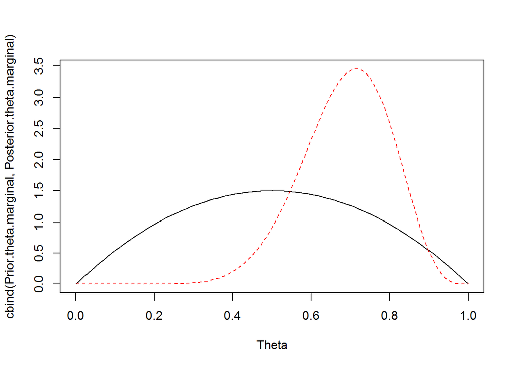

```r
matplot(Theta,cbind(Prior.theta.marginal,Posterior.theta.marginal),type="l")
```

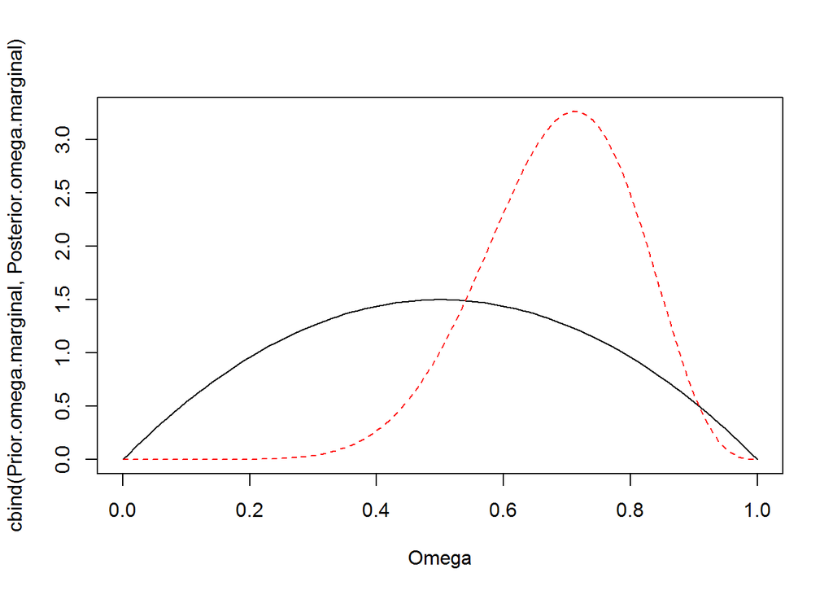

```r
matplot(Omega,cbind(Prior.omega.marginal,Posterior.omega.marginal),type="l")
```

Compare conditional priors and posteriors for $\theta$

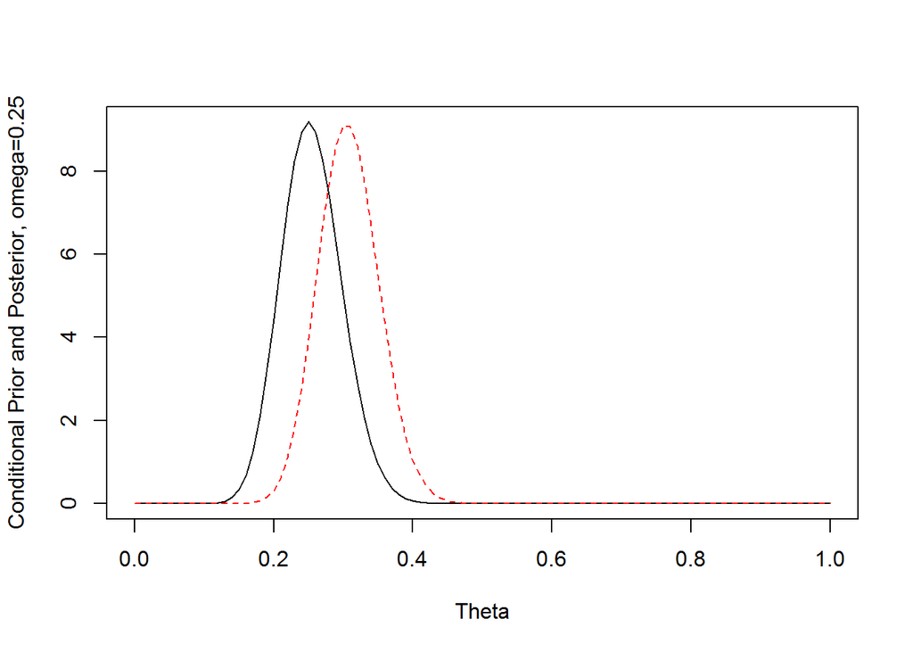

```r
matplot(Theta,cbind(Prior.theta.omega.25,Post.theta.omega.25),type="l",ylab="Conditional Prior and Posterior, omega=0.25")
```

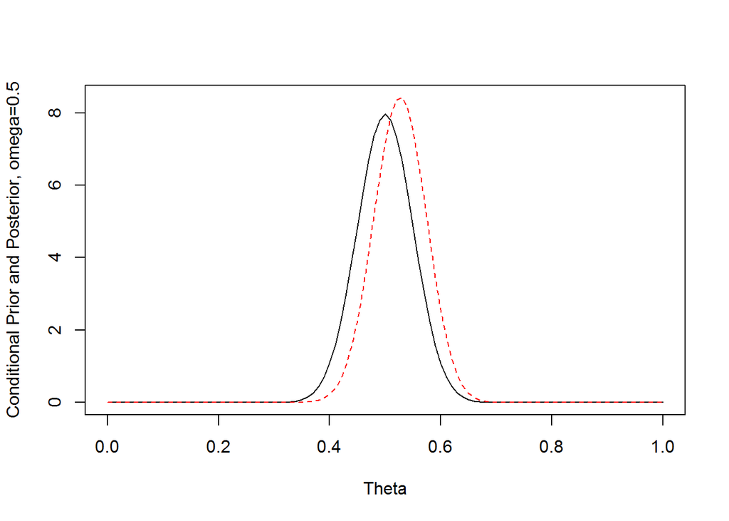

```r
matplot(Theta,cbind(Prior.theta.omega.5,Post.theta.omega.5),type="l",ylab="Conditional Prior and Posterior, omega=0.5")
```

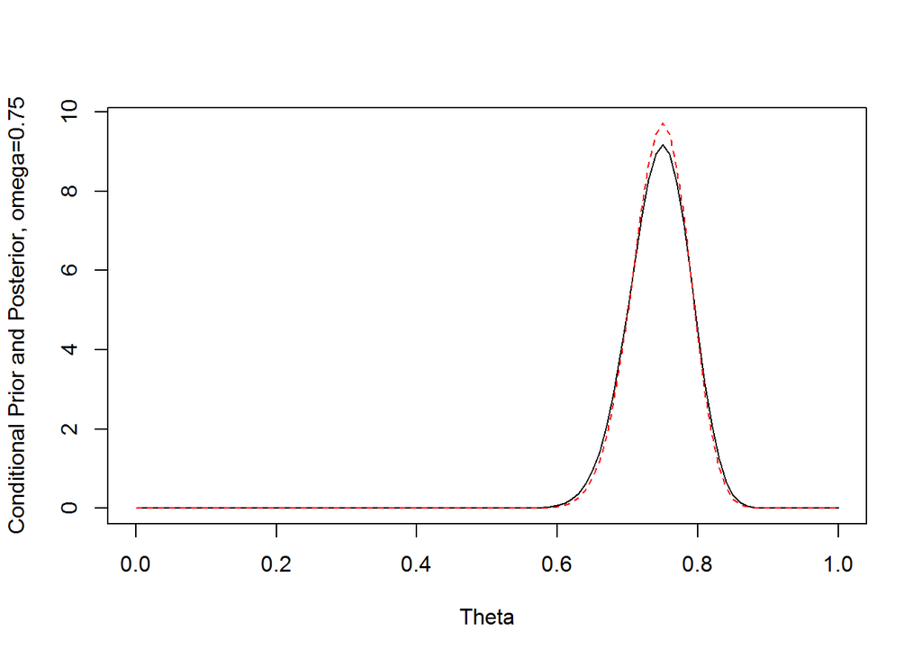

```r
matplot(Theta,cbind(Prior.theta.omega.75,Post.theta.omega.75),type="l",ylab="Conditional Prior and Posterior, omega=0.75")
```

The conditional posteriors do not differ a lot from the conditional priors.  
**What is the reason?**

## 4.2 Low concentration, more certain hyperparameter

As in the previous case the prior distribution for $\omega$ is $Beta(A_{\omega},B_{\omega}),$ where $A_{\omega}$ and $B_{\omega}$ are constants.

The model is:
$$p(\theta,\omega|y)=\frac{p(y|\theta,\omega)p(\theta,\omega)}{p(y)}=\frac{p(y|\theta)p(\theta|\omega)p(\omega)}{p(y)}.$$

Again, all 3 terms in the numerator are specified:
$$p(\omega)=Beta(A_{\omega},B_{\omega}),$$
$$p(\theta|\omega)=Beta(\omega,\kappa)$$
and the likelihood function is given by
$$y_i \sim Binom(\theta).$$

Let $\kappa=6$ be fixed and $A_{\omega}=B_{\omega}=20$. These parameters correspond to density function

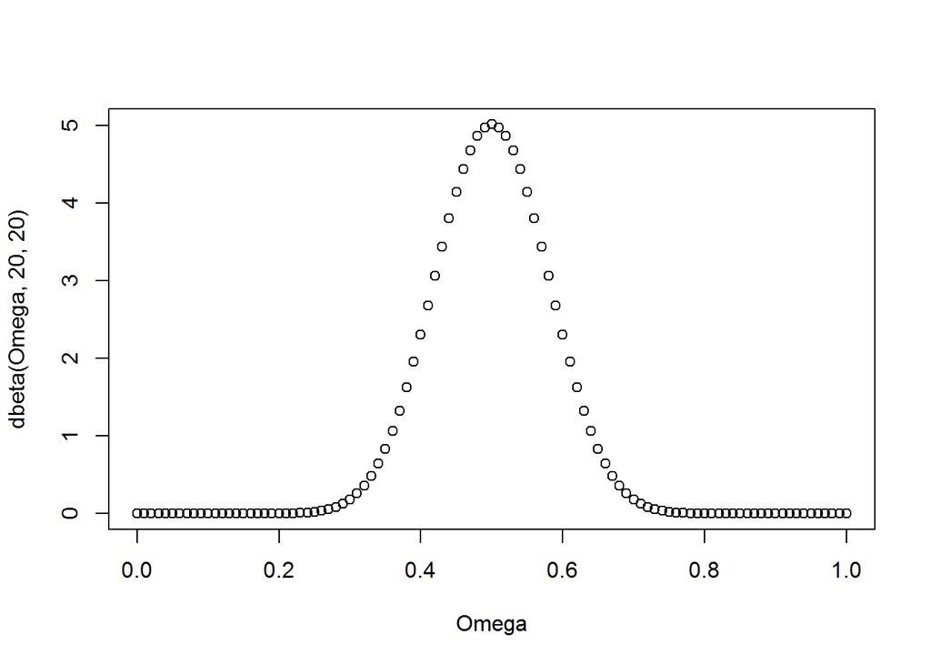

```r
Omega<-Theta<-seq( 0 , 1 , length=101 )
plot(Omega,dbeta(Omega,20,20))
```

Define parameters of the hyperprior.

```r
A_omega<-20
B_omega<-20
K<-6
```

Calculate and visualize joint prior and its marginals.

```r
jointPrior<-function(theta,omega,A_omega,B_omega,K){
  res<-dbeta(omega,A_omega,B_omega)*dbeta(theta,omega*(K-2)+1,(1-omega)*(K-2)+1)
  res
}
```

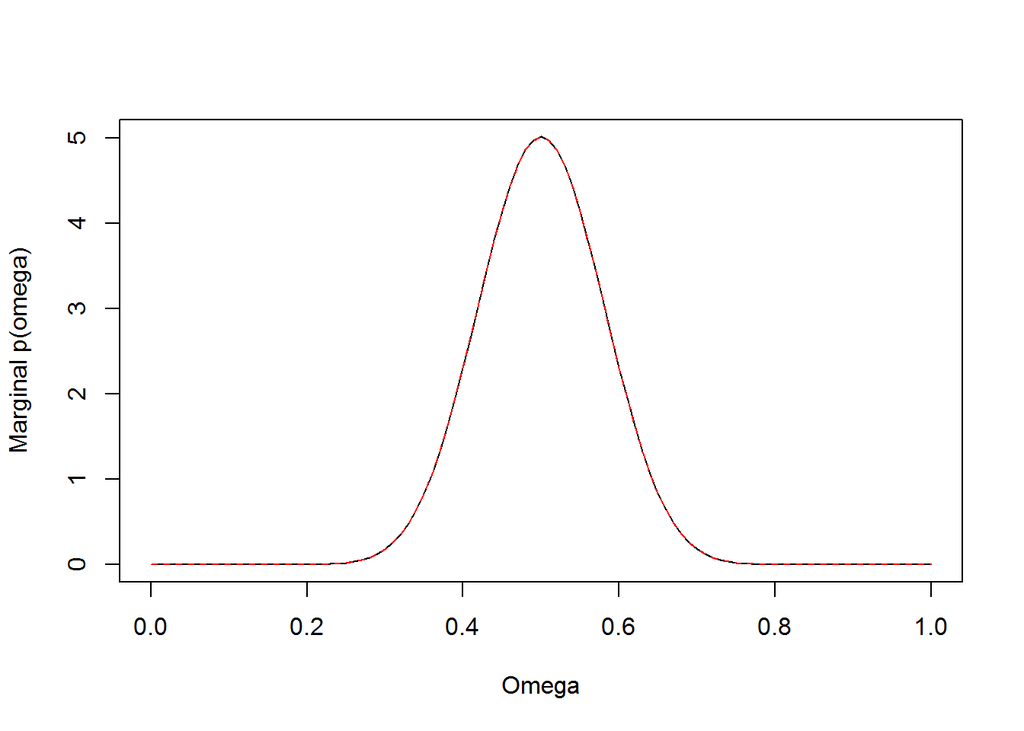

```r
dens<-expand.grid(Omega,Theta)
colnames(dens)<-c("Omega","Theta")
dens$Prior<-apply(dens,1,function(z) jointPrior(z[1],z[2],A_omega,B_omega,K))
Prior.theta.omega<-matrix(dens$Prior,101,101)
Prior.theta.omega<-Prior.theta.omega/sum(Prior.theta.omega) #Joint prior
Prior.omega.marginal<-apply(Prior.theta.omega,2,sum)
Prior.omega.marginal<-Prior.omega.marginal/sum(Prior.omega.marginal)*100 #Omega marginal prior
matplot(Omega,cbind(Prior.omega.marginal,dbeta(Omega,A_omega,B_omega)),type="l",ylab="Marginal p(omega)")
```

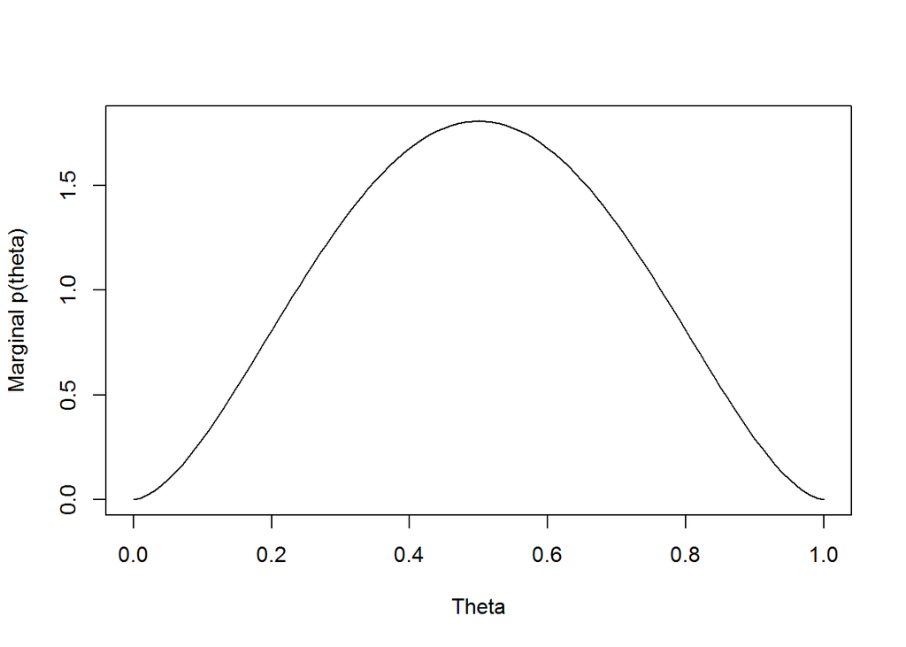

```r
Prior.theta.marginal<-apply(Prior.theta.omega,1,sum)
Prior.theta.marginal<-Prior.theta.marginal/sum(Prior.theta.marginal)*100 #Theta marginal prior
plot(Theta,Prior.theta.marginal,type="l",ylab="Marginal p(theta)")
```

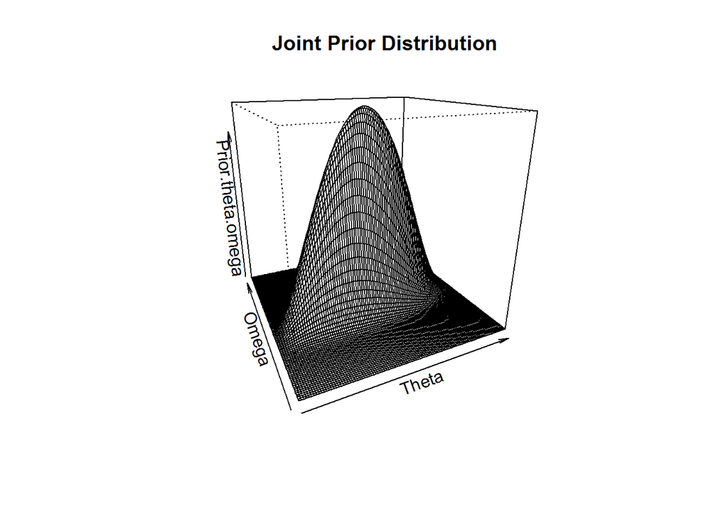

```r
persp(Theta,Omega,Prior.theta.omega,d=1,theta=-25,phi=20,main="Joint Prior Distribution")
```

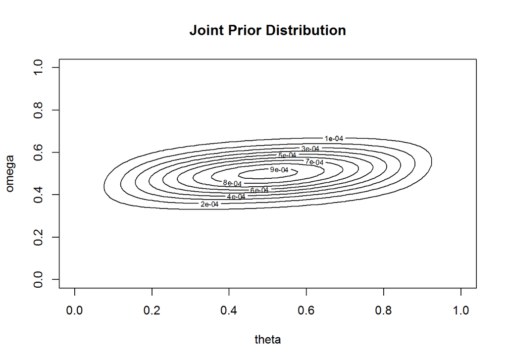

```r
contour(x=Omega,y=Theta,z=Prior.theta.omega,ylab="omega",xlab="theta",main="Joint Prior Distribution")
```

Show dependence of $\theta$ on $\omega$.

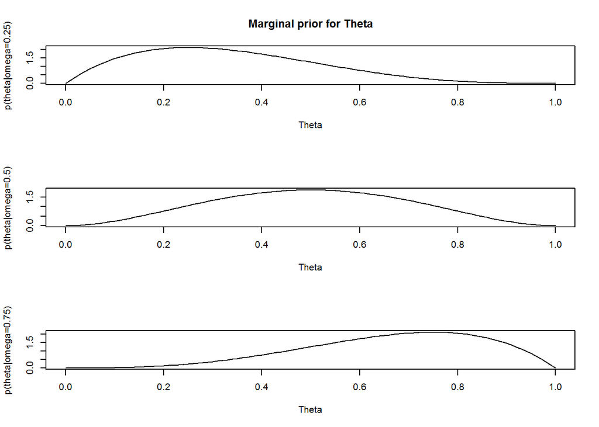

```r
par(mfrow=c(3,1))
Prior.theta.omega.25<-jointPrior(Theta,0.25,A_omega,B_omega,K)
Prior.theta.omega.25<-Prior.theta.omega.25/sum(Prior.theta.omega.25)*100
plot(Theta,Prior.theta.omega.25,type="l",ylab="p(theta|omega=0.25)",main="Marginal prior for Theta")
Prior.theta.omega.5<-jointPrior(Theta,0.5,A_omega,B_omega,K)
Prior.theta.omega.5<-Prior.theta.omega.5/sum(Prior.theta.omega.5)*100
plot(Theta,Prior.theta.omega.5,type="l",ylab="p(theta|omega=0.5)")
Prior.theta.omega.75<-jointPrior(Theta,0.75,A_omega,B_omega,K)
Prior.theta.omega.75<-Prior.theta.omega.75/sum(Prior.theta.omega.75)*100
plot(Theta,Prior.theta.omega.75,type="l",ylab="p(theta|omega=0.75)")
```

```r
par(mfrow=c(1,1))
```

The likelihood is based on the data of 9 successes out of 12 Bernoulli trials:
$$p(y|\theta)=\theta^9(1-\theta)^3.$$

```r
likeli<-function(theta,s,k){
  theta^k*(1-theta)^(s-k)
}
```

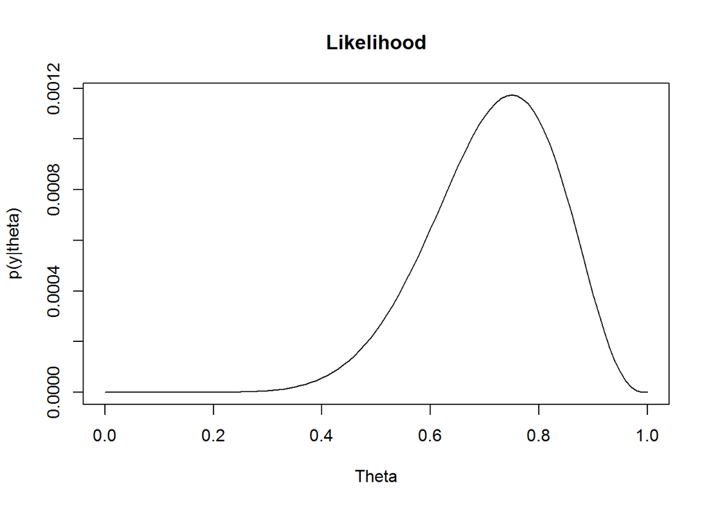

```r
likelihood<-likeli(Theta,12,9)
plot(Theta,likelihood,type="l",ylab="p(y|theta)",main="Likelihood")
```

Likelihood directly depends only on $\theta$, but not on $\omega$.

Posterior distribution is obtained by multiplication of the joint prior by likelihood at each point $(\theta_i,\omega_j)$.

(Do it yourself)

```r
Posterior<-apply(Prior.theta.omega,2,function(z) z*likelihood)
Posterior<-Posterior/sum(Posterior)
```

```r
Posterior[1:5,1:5]
```

```
##      [,1]         [,2]         [,3]         [,4]         [,5]
## [1,]    0 0.000000e+00 0.000000e+00 0.000000e+00 0.000000e+00
## [2,]    0 1.186123e-44 4.617629e-39 7.565431e-36 1.316268e-33
## [3,]    0 5.817727e-42 2.329487e-36 3.925477e-33 7.024585e-31
## [4,]    0 2.116489e-40 8.616777e-35 1.476383e-31 2.686266e-29
## [5,]    0 2.653009e-39 1.093063e-33 1.895295e-30 3.489830e-28
```

Plot the joint posterior distribution.

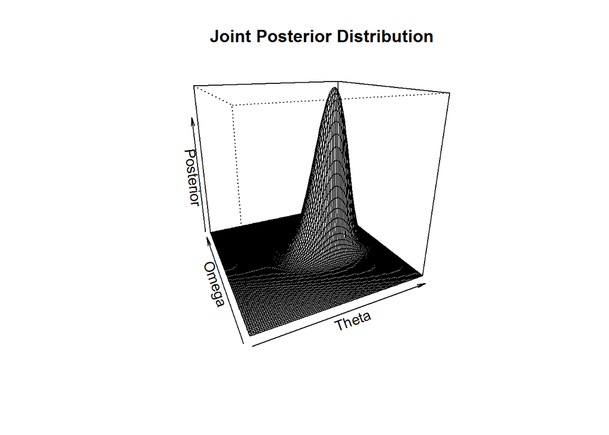

```r
persp(Theta,Omega,Posterior,d=1,theta=-25,phi=20,main="Joint Posterior Distribution")
```

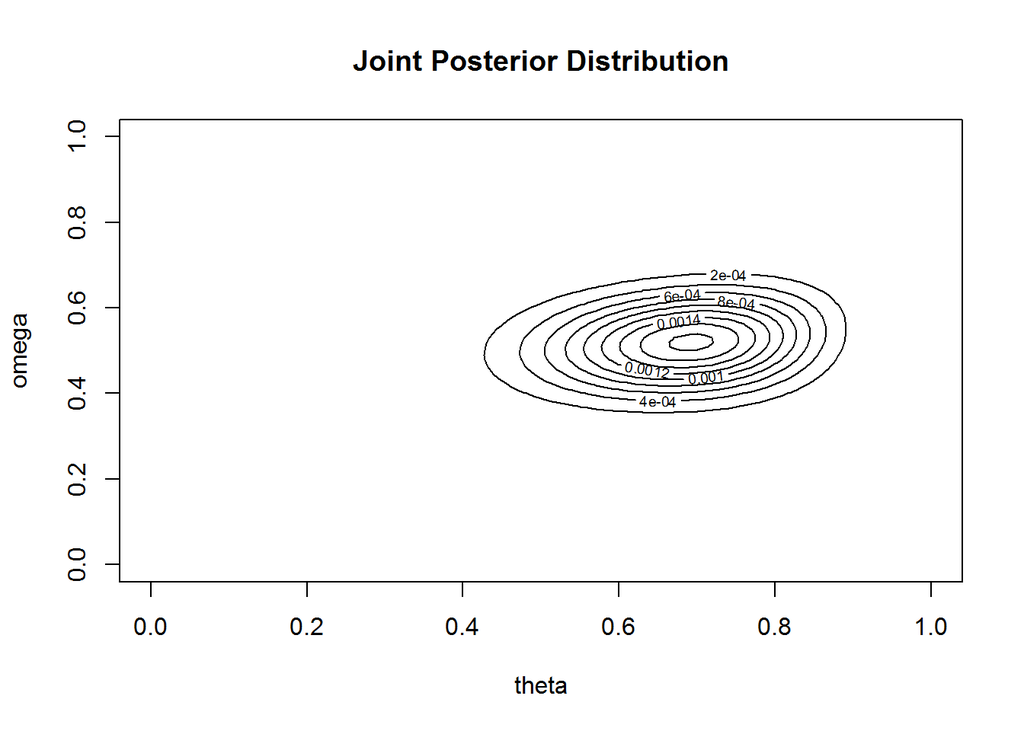

```r
contour(x=Omega,y=Theta,z=Posterior,ylab="omega",xlab="theta",main="Joint Posterior Distribution")
```

Calculate and plot posterior marginal distributions $p(\theta|y),~p(\omega|y)$ by adding the joint posterior matrix by row or by column.

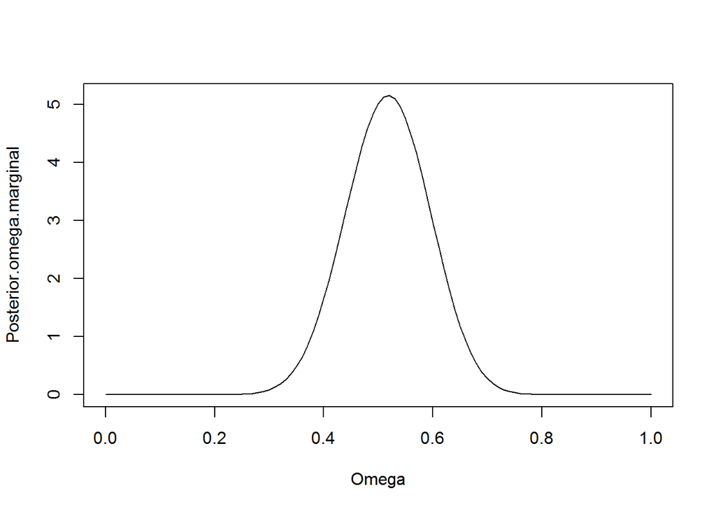

```r
Posterior.omega.marginal<-apply(Posterior,2,sum)
Posterior.omega.marginal<-Posterior.omega.marginal/sum(Posterior.omega.marginal)*100
plot(Omega,Posterior.omega.marginal,type="l")
```

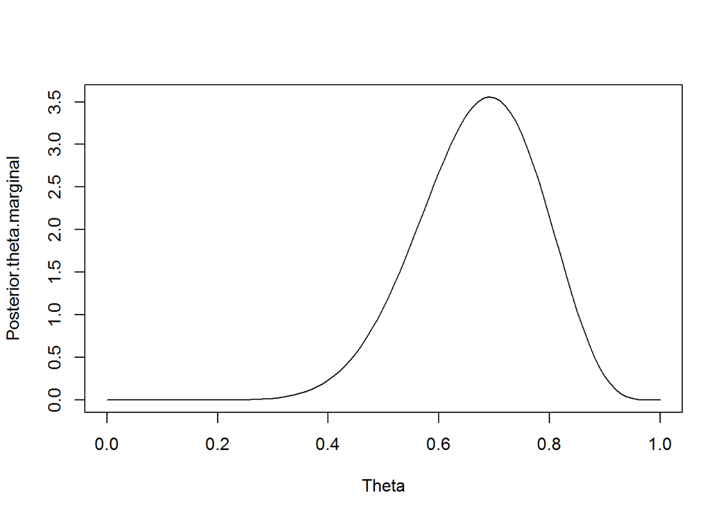

```r
Posterior.theta.marginal<-apply(Posterior,1,sum)
Posterior.theta.marginal<-Posterior.theta.marginal/sum(Posterior.theta.marginal)*100
plot(Theta,Posterior.theta.marginal,type="l")
```

Show dependence of $\theta$ on $\omega$.

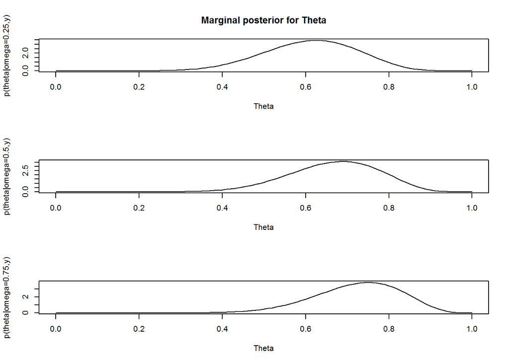

```r
par(mfrow=c(3,1))
#Omega=0.25
Post.theta.omega.25<-Posterior[,match(0.25,Omega)]
Post.theta.omega.25<-Post.theta.omega.25/sum(Post.theta.omega.25)*100
plot(Theta,Post.theta.omega.25,type="l",ylab="p(theta|omega=0.25,y)",main="Marginal posterior for Theta")
#Omega=0.5
Post.theta.omega.5<-Posterior[,match(0.5,Omega)]
Post.theta.omega.5<-Post.theta.omega.5/sum(Post.theta.omega.5)*100
plot(Theta,Post.theta.omega.5,type="l",ylab="p(theta|omega=0.5,y)")
#Omega=0.75
Post.theta.omega.75<-Posterior[,match(0.75,Omega)]
Post.theta.omega.75<-Post.theta.omega.75/sum(Post.theta.omega.75)*100
plot(Theta,Post.theta.omega.75,type="l",ylab="p(theta|omega=0.75,y)")
```

```r
par(mfrow=c(1,1))
```

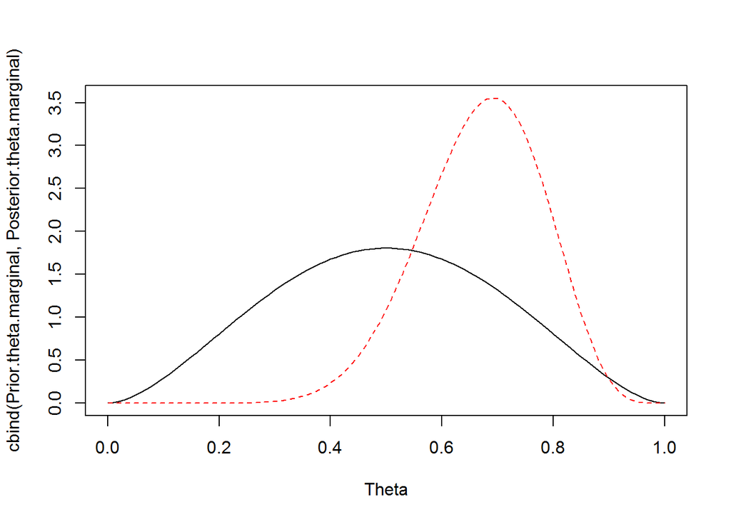

```r
matplot(Theta,cbind(Prior.theta.marginal,Posterior.theta.marginal),type="l")
```